# Expansión de la CASEN sobre el CENSO (Región 06)

VE-CC-AJ

DataIntelligence

Martes 06-07-2021

Abstract

Expandiremos los ingresos promedios comunales obtenidos de la CASEN sobre la categoría de respuesta: “Parquet, piso flotante, cerámico, madera, alfombra, flexit, cubrepiso u otro similar, sobre radier o vigas de madera” del campo P03C del CENSO de viviendas, que fue la categoría de respuesta que más alto correlaciona con los ingresos expandidos (obtenidos de la multiplicación del ingreso promedio y los habitantes), ambos a nivel comunal.

Haremos el análisis sobre la región 06.

Ensayaremos diferentes modelos dentro del análisis de regresión cuya variable independiente será: “frecuencia de población que posee la variable Censal respecto a la zona” y la dependiente: “ingreso expandido por zona”

Lo anterior para elegir el que posea el mayor coeficiente de determinación y así contruir una tabla de valores predichos.

## 1 Variable CENSO

Necesitamos calcular las frecuencias a nivel censal de las respuestas correspondientes a la categoría: “Parquet, piso flotante, cerámico, madera, alfombra, flexit, cubrepiso u otro similar, sobre radier o vigas de madera” del campo **P03C** del Censo de viviendas. Recordemos que ésta fué la más alta correlación en relación a los ingresos expandidos [(ver punto 1.2 aquí)](https://rpubs.com/dataintelligence/corr_004_viviendas).

### 1.1 Lectura y filtrado de la tabla censal de viviendas

Leemos la tabla Censo 2017 de viviendas que ya tiene integrada la clave zonal:

```r
tabla_con_clave <- readRDS("../censo_viviendas_con_clave_17.rds")
r3_100 <- tabla_con_clave[c(1:100),]
kbl(r3_100) %>%
  kable_styling(bootstrap_options = c("striped", "hover")) %>%
  kable_paper() %>%
  scroll_box(width = "100%", height = "300px")
```

| REGION | PROVINCIA | COMUNA | DC | AREA | ZC_LOC | ID_ZONA_LOC | NVIV | P01 | P02 | P03A | P03B | P03C | P04 | P05 | CANT_HOG | CANT_PER | REGION_15R | PROVINCIA_15R | COMUNA_15R | clave |
| --- | --- | --- | --- | --- | --- | --- | --- | --- | --- | --- | --- | --- | --- | --- | --- | --- | --- | --- | --- | --- |
| 15 | 152 | 15202 | 1 | 2 | 6 | 13225 | 1 | 3 | 1 | 5 | 3 | 5 | 1 | 4 | 1 | 1 | 15 | 152 | 15202 | 15202012006 |
| 15 | 152 | 15202 | 1 | 2 | 6 | 13225 | 2 | 1 | 3 | 98 | 98 | 98 | 98 | 98 | 0 | 0 | 15 | 152 | 15202 | 15202012006 |
| 15 | 152 | 15202 | 1 | 2 | 6 | 13225 | 3 | 1 | 1 | 5 | 3 | 5 | 2 | 3 | 1 | 4 | 15 | 152 | 15202 | 15202012006 |
| 15 | 152 | 15202 | 1 | 2 | 6 | 13225 | 4 | 1 | 4 | 98 | 98 | 98 | 98 | 98 | 0 | 0 | 15 | 152 | 15202 | 15202012006 |
| 15 | 152 | 15202 | 1 | 2 | 6 | 13225 | 5 | 3 | 4 | 98 | 98 | 98 | 98 | 98 | 0 | 0 | 15 | 152 | 15202 | 15202012006 |
| 15 | 152 | 15202 | 1 | 2 | 6 | 13225 | 6 | 3 | 4 | 98 | 98 | 98 | 98 | 98 | 0 | 0 | 15 | 152 | 15202 | 15202012006 |
| 15 | 152 | 15202 | 1 | 2 | 6 | 13225 | 7 | 3 | 4 | 98 | 98 | 98 | 98 | 98 | 0 | 0 | 15 | 152 | 15202 | 15202012006 |
| 15 | 152 | 15202 | 1 | 2 | 6 | 13225 | 8 | 3 | 3 | 98 | 98 | 98 | 98 | 98 | 0 | 0 | 15 | 152 | 15202 | 15202012006 |
| 15 | 152 | 15202 | 1 | 2 | 6 | 13225 | 9 | 3 | 1 | 5 | 3 | 5 | 1 | 4 | 1 | 4 | 15 | 152 | 15202 | 15202012006 |
| 15 | 152 | 15202 | 1 | 2 | 6 | 13225 | 10 | 1 | 1 | 5 | 3 | 4 | 1 | 4 | 1 | 1 | 15 | 152 | 15202 | 15202012006 |
| 15 | 152 | 15202 | 1 | 2 | 6 | 13225 | 11 | 1 | 2 | 98 | 98 | 98 | 98 | 98 | 0 | 0 | 15 | 152 | 15202 | 15202012006 |
| 15 | 152 | 15202 | 1 | 2 | 6 | 13225 | 12 | 1 | 4 | 98 | 98 | 98 | 98 | 98 | 0 | 0 | 15 | 152 | 15202 | 15202012006 |
| 15 | 152 | 15202 | 1 | 2 | 6 | 13225 | 13 | 1 | 1 | 5 | 3 | 4 | 1 | 4 | 1 | 3 | 15 | 152 | 15202 | 15202012006 |
| 15 | 152 | 15202 | 1 | 2 | 6 | 13225 | 14 | 1 | 3 | 98 | 98 | 98 | 98 | 98 | 0 | 0 | 15 | 152 | 15202 | 15202012006 |
| 15 | 152 | 15202 | 1 | 2 | 6 | 13225 | 15 | 1 | 4 | 98 | 98 | 98 | 98 | 98 | 0 | 0 | 15 | 152 | 15202 | 15202012006 |
| 15 | 152 | 15202 | 1 | 2 | 6 | 13225 | 16 | 1 | 1 | 5 | 3 | 5 | 1 | 3 | 1 | 3 | 15 | 152 | 15202 | 15202012006 |
| 15 | 152 | 15202 | 1 | 2 | 6 | 13225 | 17 | 1 | 1 | 5 | 3 | 5 | 2 | 4 | 1 | 8 | 15 | 152 | 15202 | 15202012006 |
| 15 | 152 | 15202 | 1 | 2 | 6 | 13225 | 18 | 3 | 1 | 5 | 3 | 5 | 1 | 1 | 1 | 1 | 15 | 152 | 15202 | 15202012006 |
| 15 | 152 | 15202 | 1 | 2 | 6 | 13225 | 19 | 3 | 1 | 5 | 3 | 5 | 1 | 3 | 1 | 1 | 15 | 152 | 15202 | 15202012006 |
| 15 | 152 | 15202 | 1 | 2 | 6 | 13225 | 20 | 1 | 1 | 5 | 3 | 5 | 2 | 1 | 1 | 2 | 15 | 152 | 15202 | 15202012006 |
| 15 | 152 | 15202 | 1 | 2 | 6 | 13225 | 21 | 1 | 4 | 98 | 98 | 98 | 98 | 98 | 0 | 0 | 15 | 152 | 15202 | 15202012006 |
| 15 | 152 | 15202 | 1 | 2 | 6 | 13225 | 22 | 1 | 4 | 98 | 98 | 98 | 98 | 98 | 0 | 0 | 15 | 152 | 15202 | 15202012006 |
| 15 | 152 | 15202 | 1 | 2 | 6 | 13225 | 23 | 3 | 4 | 98 | 98 | 98 | 98 | 98 | 0 | 0 | 15 | 152 | 15202 | 15202012006 |
| 15 | 152 | 15202 | 1 | 2 | 6 | 13225 | 24 | 1 | 3 | 98 | 98 | 98 | 98 | 98 | 0 | 0 | 15 | 152 | 15202 | 15202012006 |
| 15 | 152 | 15202 | 1 | 2 | 6 | 13225 | 25 | 1 | 1 | 5 | 3 | 5 | 1 | 4 | 1 | 2 | 15 | 152 | 15202 | 15202012006 |
| 15 | 152 | 15202 | 1 | 2 | 6 | 13225 | 26 | 1 | 4 | 98 | 98 | 98 | 98 | 98 | 0 | 0 | 15 | 152 | 15202 | 15202012006 |
| 15 | 152 | 15202 | 1 | 2 | 6 | 13225 | 27 | 3 | 4 | 98 | 98 | 98 | 98 | 98 | 0 | 0 | 15 | 152 | 15202 | 15202012006 |
| 15 | 152 | 15202 | 1 | 2 | 6 | 13225 | 28 | 3 | 1 | 5 | 3 | 5 | 1 | 4 | 1 | 5 | 15 | 152 | 15202 | 15202012006 |
| 15 | 152 | 15202 | 1 | 2 | 6 | 13225 | 29 | 1 | 4 | 98 | 98 | 98 | 98 | 98 | 0 | 0 | 15 | 152 | 15202 | 15202012006 |
| 15 | 152 | 15202 | 1 | 2 | 6 | 13225 | 30 | 3 | 4 | 98 | 98 | 98 | 98 | 98 | 0 | 0 | 15 | 152 | 15202 | 15202012006 |

[output cut: 70 more lines]

Despleguemos los códigos de regiones de nuestra tabla:

```r
regiones <- unique(tabla_con_clave$REGION)
```

```r
tabla_con_clave <- filter(tabla_con_clave, tabla_con_clave$REGION == 6)
tabla_con_clave <- filter(tabla_con_clave, tabla_con_clave$AREA== 1)
```

### 1.2 Cálculo de frecuencias

```r
tabla_con_clave_f <- tabla_con_clave[,-c(1,2,4,5,6,7,8,9,10,11,12,14,15,16,17,18,19,20),drop=FALSE]
```

```r
names(tabla_con_clave_f)[2] <- "Tipo de piso"
```

```r
# Ahora filtramos por Tipo de techo = 1.
tabla_con_clave_ff <- filter(tabla_con_clave_f, tabla_con_clave_f$`Tipo de piso` == 1)
```

```r
# Determinamos las frecuencias por zona:
b <- tabla_con_clave_ff$clave
c <- tabla_con_clave_ff$`Tipo de piso`
d <- tabla_con_clave_ff$COMUNA
cross_tab =  xtabs( ~ unlist(b) + unlist(c)+ unlist(d))
tabla <- as.data.frame(cross_tab)
d <-tabla[!(tabla$Freq == 0),]
names(d)[1] <- "zona"
d$anio <- "2017"
```

Veamos los primeros 100 registros:

```r
r3_100 <- d[c(1:100),]
kbl(r3_100) %>%
  kable_styling(bootstrap_options = c("striped", "hover")) %>%
  kable_paper() %>%
  scroll_box(width = "100%", height = "300px")
```

|  | zona | unlist.c. | unlist.d. | Freq | anio |
| --- | --- | --- | --- | --- | --- |
| 1 | 6101011001 | 1 | 6101 | 1185 | 2017 |
| 2 | 6101021001 | 1 | 6101 | 467 | 2017 |
| 3 | 6101031001 | 1 | 6101 | 251 | 2017 |
| 4 | 6101041001 | 1 | 6101 | 478 | 2017 |
| 5 | 6101041002 | 1 | 6101 | 1490 | 2017 |
| 6 | 6101051001 | 1 | 6101 | 749 | 2017 |
| 7 | 6101051002 | 1 | 6101 | 549 | 2017 |
| 8 | 6101051003 | 1 | 6101 | 685 | 2017 |
| 9 | 6101051004 | 1 | 6101 | 586 | 2017 |
| 10 | 6101051005 | 1 | 6101 | 466 | 2017 |
| 11 | 6101061001 | 1 | 6101 | 1223 | 2017 |
| 12 | 6101061002 | 1 | 6101 | 514 | 2017 |
| 13 | 6101061003 | 1 | 6101 | 672 | 2017 |
| 14 | 6101061004 | 1 | 6101 | 624 | 2017 |
| 15 | 6101061005 | 1 | 6101 | 646 | 2017 |
| 16 | 6101061006 | 1 | 6101 | 500 | 2017 |
| 17 | 6101061007 | 1 | 6101 | 574 | 2017 |
| 18 | 6101061008 | 1 | 6101 | 414 | 2017 |
| 19 | 6101061009 | 1 | 6101 | 495 | 2017 |
| 20 | 6101071001 | 1 | 6101 | 823 | 2017 |
| 21 | 6101071002 | 1 | 6101 | 519 | 2017 |
| 22 | 6101071003 | 1 | 6101 | 410 | 2017 |
| 23 | 6101071004 | 1 | 6101 | 739 | 2017 |
| 24 | 6101071005 | 1 | 6101 | 136 | 2017 |
| 25 | 6101071006 | 1 | 6101 | 482 | 2017 |
| 26 | 6101071007 | 1 | 6101 | 290 | 2017 |
| 27 | 6101081001 | 1 | 6101 | 465 | 2017 |
| 28 | 6101081002 | 1 | 6101 | 762 | 2017 |
| 29 | 6101081003 | 1 | 6101 | 865 | 2017 |
| 30 | 6101081004 | 1 | 6101 | 828 | 2017 |

[output cut: 70 more lines]

Agregamos un cero a los códigos comunales de cuatro dígitos:

```r
codigos <- d$unlist.d.
rango <- seq(1:nrow(d))
cadena <- paste("0",codigos[rango], sep = "")
cadena <- substr(cadena,(nchar(cadena)[rango])-(4),6)
codigos <- as.data.frame(codigos)
cadena <- as.data.frame(cadena)
comuna_corr <- cbind(d,cadena)
comuna_corr <- comuna_corr[,-c(2,3),drop=FALSE]
names(comuna_corr)[4] <- "código"
r3_100 <- comuna_corr[c(1:100),]
kbl(r3_100) %>%
  kable_styling(bootstrap_options = c("striped", "hover")) %>%
  kable_paper() %>%
  scroll_box(width = "100%", height = "300px")
```

|  | zona | Freq | anio | código |
| --- | --- | --- | --- | --- |
| 1 | 6101011001 | 1185 | 2017 | 06101 |
| 2 | 6101021001 | 467 | 2017 | 06101 |
| 3 | 6101031001 | 251 | 2017 | 06101 |
| 4 | 6101041001 | 478 | 2017 | 06101 |
| 5 | 6101041002 | 1490 | 2017 | 06101 |
| 6 | 6101051001 | 749 | 2017 | 06101 |
| 7 | 6101051002 | 549 | 2017 | 06101 |
| 8 | 6101051003 | 685 | 2017 | 06101 |
| 9 | 6101051004 | 586 | 2017 | 06101 |
| 10 | 6101051005 | 466 | 2017 | 06101 |
| 11 | 6101061001 | 1223 | 2017 | 06101 |
| 12 | 6101061002 | 514 | 2017 | 06101 |
| 13 | 6101061003 | 672 | 2017 | 06101 |
| 14 | 6101061004 | 624 | 2017 | 06101 |
| 15 | 6101061005 | 646 | 2017 | 06101 |
| 16 | 6101061006 | 500 | 2017 | 06101 |
| 17 | 6101061007 | 574 | 2017 | 06101 |
| 18 | 6101061008 | 414 | 2017 | 06101 |
| 19 | 6101061009 | 495 | 2017 | 06101 |
| 20 | 6101071001 | 823 | 2017 | 06101 |
| 21 | 6101071002 | 519 | 2017 | 06101 |
| 22 | 6101071003 | 410 | 2017 | 06101 |
| 23 | 6101071004 | 739 | 2017 | 06101 |
| 24 | 6101071005 | 136 | 2017 | 06101 |
| 25 | 6101071006 | 482 | 2017 | 06101 |
| 26 | 6101071007 | 290 | 2017 | 06101 |
| 27 | 6101081001 | 465 | 2017 | 06101 |
| 28 | 6101081002 | 762 | 2017 | 06101 |
| 29 | 6101081003 | 865 | 2017 | 06101 |
| 30 | 6101081004 | 828 | 2017 | 06101 |

[output cut: 70 more lines]

## 2 Variable CASEN

### 2.1 Tabla de ingresos expandidos

Hemos calculado ya éste valor como conclusión del punto 1.1 de [aquí](https://rpubs.com/dataintelligence/corr_casen_censo_002)

```r
h_y_m_2017_censo <- readRDS("../ingresos_expandidos_urbano_17.rds")
tablamadre <- head(h_y_m_2017_censo,50)
kbl(tablamadre) %>%
  kable_styling(bootstrap_options = c("striped", "hover")) %>%
  kable_paper() %>%
  scroll_box(width = "100%", height = "300px")
```

| código | comuna.x | promedio_i | año | comuna.y | personas | Ingresos_expandidos |
| --- | --- | --- | --- | --- | --- | --- |
| 01101 | Iquique | 375676.9 | 2017 | 1101 | 191468 | 71930106513 |
| 01107 | Alto Hospicio | 311571.7 | 2017 | 1107 | 108375 | 33766585496 |
| 01401 | Pozo Almonte | 316138.5 | 2017 | 1401 | 15711 | 4966851883 |
| 01405 | Pica | 330061.1 | 2017 | 1405 | 9296 | 3068247619 |
| 02101 | Antofagasta | 368221.4 | 2017 | 2101 | 361873 | 133249367039 |
| 02102 | Mejillones | 369770.7 | 2017 | 2102 | 13467 | 4979702302 |
| 02104 | Taltal | 383666.2 | 2017 | 2104 | 13317 | 5109282942 |
| 02201 | Calama | 434325.1 | 2017 | 2201 | 165731 | 71981127235 |
| 02203 | San Pedro de Atacama | 442861.0 | 2017 | 2203 | 10996 | 4869699464 |
| 02301 | Tocopilla | 286187.2 | 2017 | 2301 | 25186 | 7207910819 |
| 02302 | María Elena | 477748.0 | 2017 | 2302 | 6457 | 3084818966 |
| 03101 | Copiapó | 343121.0 | 2017 | 3101 | 153937 | 52819016037 |
| 03102 | Caldera | 318653.2 | 2017 | 3102 | 17662 | 5628052276 |
| 03103 | Tierra Amarilla | 333194.9 | 2017 | 3103 | 14019 | 4671058718 |
| 03201 | Chañaral | 286389.3 | 2017 | 3201 | 12219 | 3499391196 |
| 03202 | Diego de Almagro | 351583.9 | 2017 | 3202 | 13925 | 4895805596 |
| 03301 | Vallenar | 315981.5 | 2017 | 3301 | 51917 | 16404810756 |
| 03303 | Freirina | 289049.9 | 2017 | 3303 | 7041 | 2035200054 |
| 03304 | Huasco | 337414.8 | 2017 | 3304 | 10149 | 3424422750 |
| 04101 | La Serena | 279340.1 | 2017 | 4101 | 221054 | 61749247282 |
| 04102 | Coquimbo | 269078.6 | 2017 | 4102 | 227730 | 61277269093 |
| 04103 | Andacollo | 258539.7 | 2017 | 4103 | 11044 | 2855312920 |
| 04104 | La Higuera | 214257.0 | 2017 | 4104 | 4241 | 908664019 |
| 04106 | Vicuña | 254177.0 | 2017 | 4106 | 27771 | 7058750373 |
| 04201 | Illapel | 282139.3 | 2017 | 4201 | 30848 | 8703433491 |
| 04202 | Canela | 233397.3 | 2017 | 4202 | 9093 | 2122281844 |
| 04203 | Los Vilos | 285214.0 | 2017 | 4203 | 21382 | 6098444926 |
| 04204 | Salamanca | 262056.9 | 2017 | 4204 | 29347 | 7690585032 |
| 04301 | Ovalle | 280373.5 | 2017 | 4301 | 111272 | 31197719080 |
| 04302 | Combarbalá | 234537.3 | 2017 | 4302 | 13322 | 3124505460 |
| 04303 | Monte Patria | 225369.1 | 2017 | 4303 | 30751 | 6930326684 |
| 04304 | Punitaqui | 212496.1 | 2017 | 4304 | 10956 | 2328107498 |
| 05101 | Valparaíso | 306572.5 | 2017 | 5101 | 296655 | 90946261553 |
| 05102 | Casablanca | 348088.6 | 2017 | 5102 | 26867 | 9352095757 |
| 05103 | Concón | 333932.4 | 2017 | 5103 | 42152 | 14075920021 |
| 05105 | Puchuncaví | 296035.5 | 2017 | 5105 | 18546 | 5490274928 |
| 05107 | Quintero | 308224.7 | 2017 | 5107 | 31923 | 9839456903 |
| 05109 | Viña del Mar | 354715.9 | 2017 | 5109 | 334248 | 118563074323 |
| 05301 | Los Andes | 355446.2 | 2017 | 5301 | 66708 | 23711104774 |
| 05302 | Calle Larga | 246387.3 | 2017 | 5302 | 14832 | 3654416747 |
| 05303 | Rinconada | 279807.9 | 2017 | 5303 | 10207 | 2855998928 |
| 05304 | San Esteban | 219571.6 | 2017 | 5304 | 18855 | 4140022481 |
| 05401 | La Ligua | 259482.3 | 2017 | 5401 | 35390 | 9183080280 |
| 05402 | Cabildo | 262745.9 | 2017 | 5402 | 19388 | 5094117762 |
| 05403 | Papudo | 302317.1 | 2017 | 5403 | 6356 | 1921527704 |
| 05404 | Petorca | 237510.8 | 2017 | 5404 | 9826 | 2333781007 |
| 05405 | Zapallar | 294389.2 | 2017 | 5405 | 7339 | 2160521991 |
| 05501 | Quillota | 288694.2 | 2017 | 5501 | 90517 | 26131733924 |
| 05502 | Calera | 282823.6 | 2017 | 5502 | 50554 | 14297866792 |
| 05503 | Hijuelas | 268449.7 | 2017 | 5503 | 17988 | 4828872604 |

## 3 Unión Censo-Casen

Integramos a la tabla censal de frecuencias la tabla de ingresos expandidos de la Casen.

```r
comunas_con_ing_exp = merge( x = comuna_corr, y = h_y_m_2017_censo, by = "código", all.x = TRUE)
comunas_con_ing_exp <-comunas_con_ing_exp[!(is.na(comunas_con_ing_exp$Ingresos_expandidos)),]
r3_100 <- comunas_con_ing_exp[c(1:100),]
kbl(r3_100) %>%
  kable_styling(bootstrap_options = c("striped", "hover")) %>%
  kable_paper() %>%
  scroll_box(width = "100%", height = "300px")
```

| código | zona | Freq | anio | comuna.x | promedio_i | año | comuna.y | personas | Ingresos_expandidos |
| --- | --- | --- | --- | --- | --- | --- | --- | --- | --- |
| 06101 | 6101011001 | 1185 | 2017 | Rancagua | 318384.5 | 2017 | 6101 | 241774 | 76977097284 |
| 06101 | 6101021001 | 467 | 2017 | Rancagua | 318384.5 | 2017 | 6101 | 241774 | 76977097284 |
| 06101 | 6101031001 | 251 | 2017 | Rancagua | 318384.5 | 2017 | 6101 | 241774 | 76977097284 |
| 06101 | 6101041001 | 478 | 2017 | Rancagua | 318384.5 | 2017 | 6101 | 241774 | 76977097284 |
| 06101 | 6101041002 | 1490 | 2017 | Rancagua | 318384.5 | 2017 | 6101 | 241774 | 76977097284 |
| 06101 | 6101051001 | 749 | 2017 | Rancagua | 318384.5 | 2017 | 6101 | 241774 | 76977097284 |
| 06101 | 6101051002 | 549 | 2017 | Rancagua | 318384.5 | 2017 | 6101 | 241774 | 76977097284 |
| 06101 | 6101051003 | 685 | 2017 | Rancagua | 318384.5 | 2017 | 6101 | 241774 | 76977097284 |
| 06101 | 6101051004 | 586 | 2017 | Rancagua | 318384.5 | 2017 | 6101 | 241774 | 76977097284 |
| 06101 | 6101051005 | 466 | 2017 | Rancagua | 318384.5 | 2017 | 6101 | 241774 | 76977097284 |
| 06101 | 6101061001 | 1223 | 2017 | Rancagua | 318384.5 | 2017 | 6101 | 241774 | 76977097284 |
| 06101 | 6101061002 | 514 | 2017 | Rancagua | 318384.5 | 2017 | 6101 | 241774 | 76977097284 |
| 06101 | 6101061003 | 672 | 2017 | Rancagua | 318384.5 | 2017 | 6101 | 241774 | 76977097284 |
| 06101 | 6101061004 | 624 | 2017 | Rancagua | 318384.5 | 2017 | 6101 | 241774 | 76977097284 |
| 06101 | 6101061005 | 646 | 2017 | Rancagua | 318384.5 | 2017 | 6101 | 241774 | 76977097284 |
| 06101 | 6101061006 | 500 | 2017 | Rancagua | 318384.5 | 2017 | 6101 | 241774 | 76977097284 |
| 06101 | 6101061007 | 574 | 2017 | Rancagua | 318384.5 | 2017 | 6101 | 241774 | 76977097284 |
| 06101 | 6101061008 | 414 | 2017 | Rancagua | 318384.5 | 2017 | 6101 | 241774 | 76977097284 |
| 06101 | 6101061009 | 495 | 2017 | Rancagua | 318384.5 | 2017 | 6101 | 241774 | 76977097284 |
| 06101 | 6101071001 | 823 | 2017 | Rancagua | 318384.5 | 2017 | 6101 | 241774 | 76977097284 |
| 06101 | 6101071002 | 519 | 2017 | Rancagua | 318384.5 | 2017 | 6101 | 241774 | 76977097284 |
| 06101 | 6101071003 | 410 | 2017 | Rancagua | 318384.5 | 2017 | 6101 | 241774 | 76977097284 |
| 06101 | 6101071004 | 739 | 2017 | Rancagua | 318384.5 | 2017 | 6101 | 241774 | 76977097284 |
| 06101 | 6101071005 | 136 | 2017 | Rancagua | 318384.5 | 2017 | 6101 | 241774 | 76977097284 |
| 06101 | 6101071006 | 482 | 2017 | Rancagua | 318384.5 | 2017 | 6101 | 241774 | 76977097284 |
| 06101 | 6101071007 | 290 | 2017 | Rancagua | 318384.5 | 2017 | 6101 | 241774 | 76977097284 |
| 06101 | 6101081001 | 465 | 2017 | Rancagua | 318384.5 | 2017 | 6101 | 241774 | 76977097284 |
| 06101 | 6101081002 | 762 | 2017 | Rancagua | 318384.5 | 2017 | 6101 | 241774 | 76977097284 |
| 06101 | 6101081003 | 865 | 2017 | Rancagua | 318384.5 | 2017 | 6101 | 241774 | 76977097284 |
| 06101 | 6101081004 | 828 | 2017 | Rancagua | 318384.5 | 2017 | 6101 | 241774 | 76977097284 |

[output cut: 70 more lines]

## 4 Proporción poblacional zonal respecto a la comunal

Del censo obtenemos la cantidad de población a nivel de zona y estimamos su proporción a nivel comunal. Ya hemos calculado ésta proporción [aquí](https://rpubs.com/dataintelligence/tabla_de_proporciones).

```r
prop_pob <- readRDS("../tabla_de_prop_pob.rds")
names(prop_pob)[1] <- "zona"
names(prop_pob)[3] <- "p_poblacional"
```

Veamos los 100 primeros registros:

```r
r3_100 <- prop_pob[c(1:100),]
kbl(r3_100) %>%
  kable_styling(bootstrap_options = c("striped", "hover")) %>%
  kable_paper() %>%
  scroll_box(width = "100%", height = "300px")
```

| zona | Freq | p_poblacional | código |
| --- | --- | --- | --- |
| 1101011001 | 2491 | 0.0130100 | 01101 |
| 1101011002 | 1475 | 0.0077036 | 01101 |
| 1101021001 | 1003 | 0.0052385 | 01101 |
| 1101021002 | 54 | 0.0002820 | 01101 |
| 1101021003 | 2895 | 0.0151200 | 01101 |
| 1101021004 | 2398 | 0.0125243 | 01101 |
| 1101021005 | 4525 | 0.0236332 | 01101 |
| 1101031001 | 2725 | 0.0142321 | 01101 |
| 1101031002 | 3554 | 0.0185618 | 01101 |
| 1101031003 | 5246 | 0.0273988 | 01101 |
| 1101031004 | 3389 | 0.0177001 | 01101 |
| 1101041001 | 1800 | 0.0094010 | 01101 |
| 1101041002 | 2538 | 0.0132555 | 01101 |
| 1101041003 | 3855 | 0.0201339 | 01101 |
| 1101041004 | 5663 | 0.0295767 | 01101 |
| 1101041005 | 4162 | 0.0217373 | 01101 |
| 1101041006 | 2689 | 0.0140441 | 01101 |
| 1101051001 | 3296 | 0.0172144 | 01101 |
| 1101051002 | 4465 | 0.0233198 | 01101 |
| 1101051003 | 4656 | 0.0243174 | 01101 |
| 1101051004 | 2097 | 0.0109522 | 01101 |
| 1101051005 | 3569 | 0.0186402 | 01101 |
| 1101051006 | 2741 | 0.0143157 | 01101 |
| 1101061001 | 1625 | 0.0084871 | 01101 |
| 1101061002 | 4767 | 0.0248971 | 01101 |
| 1101061003 | 4826 | 0.0252053 | 01101 |
| 1101061004 | 4077 | 0.0212934 | 01101 |
| 1101061005 | 2166 | 0.0113126 | 01101 |
| 1101071001 | 2324 | 0.0121378 | 01101 |
| 1101071002 | 2801 | 0.0146291 | 01101 |

[output cut: 70 more lines]

## 5 Ingreso medio

Deseamos el valor del ingreso promedio a nivel comunal, pero expandido a nivel zonal. Ésta información está contenida en el campo promedio_i de la tabla obtenida en el punto 3.

```r
r3_100 <- comunas_con_ing_exp[c(1:100),]
kbl(r3_100) %>%
  kable_styling(bootstrap_options = c("striped", "hover")) %>%
  kable_paper() %>%
  scroll_box(width = "100%", height = "300px")
```

| código | zona | Freq | anio | comuna.x | promedio_i | año | comuna.y | personas | Ingresos_expandidos |
| --- | --- | --- | --- | --- | --- | --- | --- | --- | --- |
| 06101 | 6101011001 | 1185 | 2017 | Rancagua | 318384.5 | 2017 | 6101 | 241774 | 76977097284 |
| 06101 | 6101021001 | 467 | 2017 | Rancagua | 318384.5 | 2017 | 6101 | 241774 | 76977097284 |
| 06101 | 6101031001 | 251 | 2017 | Rancagua | 318384.5 | 2017 | 6101 | 241774 | 76977097284 |
| 06101 | 6101041001 | 478 | 2017 | Rancagua | 318384.5 | 2017 | 6101 | 241774 | 76977097284 |
| 06101 | 6101041002 | 1490 | 2017 | Rancagua | 318384.5 | 2017 | 6101 | 241774 | 76977097284 |
| 06101 | 6101051001 | 749 | 2017 | Rancagua | 318384.5 | 2017 | 6101 | 241774 | 76977097284 |
| 06101 | 6101051002 | 549 | 2017 | Rancagua | 318384.5 | 2017 | 6101 | 241774 | 76977097284 |
| 06101 | 6101051003 | 685 | 2017 | Rancagua | 318384.5 | 2017 | 6101 | 241774 | 76977097284 |
| 06101 | 6101051004 | 586 | 2017 | Rancagua | 318384.5 | 2017 | 6101 | 241774 | 76977097284 |
| 06101 | 6101051005 | 466 | 2017 | Rancagua | 318384.5 | 2017 | 6101 | 241774 | 76977097284 |
| 06101 | 6101061001 | 1223 | 2017 | Rancagua | 318384.5 | 2017 | 6101 | 241774 | 76977097284 |
| 06101 | 6101061002 | 514 | 2017 | Rancagua | 318384.5 | 2017 | 6101 | 241774 | 76977097284 |
| 06101 | 6101061003 | 672 | 2017 | Rancagua | 318384.5 | 2017 | 6101 | 241774 | 76977097284 |
| 06101 | 6101061004 | 624 | 2017 | Rancagua | 318384.5 | 2017 | 6101 | 241774 | 76977097284 |
| 06101 | 6101061005 | 646 | 2017 | Rancagua | 318384.5 | 2017 | 6101 | 241774 | 76977097284 |
| 06101 | 6101061006 | 500 | 2017 | Rancagua | 318384.5 | 2017 | 6101 | 241774 | 76977097284 |
| 06101 | 6101061007 | 574 | 2017 | Rancagua | 318384.5 | 2017 | 6101 | 241774 | 76977097284 |
| 06101 | 6101061008 | 414 | 2017 | Rancagua | 318384.5 | 2017 | 6101 | 241774 | 76977097284 |
| 06101 | 6101061009 | 495 | 2017 | Rancagua | 318384.5 | 2017 | 6101 | 241774 | 76977097284 |
| 06101 | 6101071001 | 823 | 2017 | Rancagua | 318384.5 | 2017 | 6101 | 241774 | 76977097284 |
| 06101 | 6101071002 | 519 | 2017 | Rancagua | 318384.5 | 2017 | 6101 | 241774 | 76977097284 |
| 06101 | 6101071003 | 410 | 2017 | Rancagua | 318384.5 | 2017 | 6101 | 241774 | 76977097284 |
| 06101 | 6101071004 | 739 | 2017 | Rancagua | 318384.5 | 2017 | 6101 | 241774 | 76977097284 |
| 06101 | 6101071005 | 136 | 2017 | Rancagua | 318384.5 | 2017 | 6101 | 241774 | 76977097284 |
| 06101 | 6101071006 | 482 | 2017 | Rancagua | 318384.5 | 2017 | 6101 | 241774 | 76977097284 |
| 06101 | 6101071007 | 290 | 2017 | Rancagua | 318384.5 | 2017 | 6101 | 241774 | 76977097284 |
| 06101 | 6101081001 | 465 | 2017 | Rancagua | 318384.5 | 2017 | 6101 | 241774 | 76977097284 |
| 06101 | 6101081002 | 762 | 2017 | Rancagua | 318384.5 | 2017 | 6101 | 241774 | 76977097284 |
| 06101 | 6101081003 | 865 | 2017 | Rancagua | 318384.5 | 2017 | 6101 | 241774 | 76977097284 |
| 06101 | 6101081004 | 828 | 2017 | Rancagua | 318384.5 | 2017 | 6101 | 241774 | 76977097284 |

[output cut: 70 more lines]

## 6 Ingreso promedio expandido por zona (**multi_pob**)

En éste momento vamos a construir nuestra variable dependiente de regresión aplicando la siguiente fórmula:

$$multi\_pob = promedio\_i \cdot personas \cdot p\_poblacional$$

Para ello integramos a la tabla de ingresos expandidos a nivel zonal (punto 3) la tabla de proporciones poblacionales zonales respecto al total comunal (punto 4) :

```r
h_y_m_comuna_corr_01 = merge( x = comunas_con_ing_exp, y = prop_pob, by = "zona", all.x = TRUE)
tablamadre <- head(h_y_m_comuna_corr_01,100)
kbl(tablamadre) %>%
  kable_styling(bootstrap_options = c("striped", "hover")) %>%
  kable_paper() %>%
  scroll_box(width = "100%", height = "300px")
```

| zona | código.x | Freq.x | anio | comuna.x | promedio_i | año | comuna.y | personas | Ingresos_expandidos | Freq.y | p_poblacional | código.y |
| --- | --- | --- | --- | --- | --- | --- | --- | --- | --- | --- | --- | --- |
| 6101011001 | 06101 | 1185 | 2017 | Rancagua | 318384.5 | 2017 | 6101 | 241774 | 76977097284 | 2931 | 0.0121229 | 06101 |
| 6101021001 | 06101 | 467 | 2017 | Rancagua | 318384.5 | 2017 | 6101 | 241774 | 76977097284 | 1326 | 0.0054845 | 06101 |
| 6101031001 | 06101 | 251 | 2017 | Rancagua | 318384.5 | 2017 | 6101 | 241774 | 76977097284 | 893 | 0.0036935 | 06101 |
| 6101041001 | 06101 | 478 | 2017 | Rancagua | 318384.5 | 2017 | 6101 | 241774 | 76977097284 | 1599 | 0.0066136 | 06101 |
| 6101041002 | 06101 | 1490 | 2017 | Rancagua | 318384.5 | 2017 | 6101 | 241774 | 76977097284 | 3616 | 0.0149561 | 06101 |
| 6101051001 | 06101 | 749 | 2017 | Rancagua | 318384.5 | 2017 | 6101 | 241774 | 76977097284 | 2105 | 0.0087065 | 06101 |
| 6101051002 | 06101 | 549 | 2017 | Rancagua | 318384.5 | 2017 | 6101 | 241774 | 76977097284 | 1634 | 0.0067584 | 06101 |
| 6101051003 | 06101 | 685 | 2017 | Rancagua | 318384.5 | 2017 | 6101 | 241774 | 76977097284 | 1810 | 0.0074863 | 06101 |
| 6101051004 | 06101 | 586 | 2017 | Rancagua | 318384.5 | 2017 | 6101 | 241774 | 76977097284 | 1724 | 0.0071306 | 06101 |
| 6101051005 | 06101 | 466 | 2017 | Rancagua | 318384.5 | 2017 | 6101 | 241774 | 76977097284 | 1297 | 0.0053645 | 06101 |
| 6101061001 | 06101 | 1223 | 2017 | Rancagua | 318384.5 | 2017 | 6101 | 241774 | 76977097284 | 3575 | 0.0147865 | 06101 |
| 6101061002 | 06101 | 514 | 2017 | Rancagua | 318384.5 | 2017 | 6101 | 241774 | 76977097284 | 1868 | 0.0077262 | 06101 |
| 6101061003 | 06101 | 672 | 2017 | Rancagua | 318384.5 | 2017 | 6101 | 241774 | 76977097284 | 1945 | 0.0080447 | 06101 |
| 6101061004 | 06101 | 624 | 2017 | Rancagua | 318384.5 | 2017 | 6101 | 241774 | 76977097284 | 2013 | 0.0083260 | 06101 |
| 6101061005 | 06101 | 646 | 2017 | Rancagua | 318384.5 | 2017 | 6101 | 241774 | 76977097284 | 1941 | 0.0080282 | 06101 |
| 6101061006 | 06101 | 500 | 2017 | Rancagua | 318384.5 | 2017 | 6101 | 241774 | 76977097284 | 1440 | 0.0059560 | 06101 |
| 6101061007 | 06101 | 574 | 2017 | Rancagua | 318384.5 | 2017 | 6101 | 241774 | 76977097284 | 1880 | 0.0077759 | 06101 |
| 6101061008 | 06101 | 414 | 2017 | Rancagua | 318384.5 | 2017 | 6101 | 241774 | 76977097284 | 1255 | 0.0051908 | 06101 |
| 6101061009 | 06101 | 495 | 2017 | Rancagua | 318384.5 | 2017 | 6101 | 241774 | 76977097284 | 1458 | 0.0060304 | 06101 |
| 6101071001 | 06101 | 823 | 2017 | Rancagua | 318384.5 | 2017 | 6101 | 241774 | 76977097284 | 3085 | 0.0127599 | 06101 |
| 6101071002 | 06101 | 519 | 2017 | Rancagua | 318384.5 | 2017 | 6101 | 241774 | 76977097284 | 1951 | 0.0080695 | 06101 |
| 6101071003 | 06101 | 410 | 2017 | Rancagua | 318384.5 | 2017 | 6101 | 241774 | 76977097284 | 1805 | 0.0074656 | 06101 |
| 6101071004 | 06101 | 739 | 2017 | Rancagua | 318384.5 | 2017 | 6101 | 241774 | 76977097284 | 2369 | 0.0097984 | 06101 |
| 6101071005 | 06101 | 136 | 2017 | Rancagua | 318384.5 | 2017 | 6101 | 241774 | 76977097284 | 411 | 0.0016999 | 06101 |
| 6101071006 | 06101 | 482 | 2017 | Rancagua | 318384.5 | 2017 | 6101 | 241774 | 76977097284 | 1821 | 0.0075318 | 06101 |
| 6101071007 | 06101 | 290 | 2017 | Rancagua | 318384.5 | 2017 | 6101 | 241774 | 76977097284 | 1281 | 0.0052983 | 06101 |
| 6101081001 | 06101 | 465 | 2017 | Rancagua | 318384.5 | 2017 | 6101 | 241774 | 76977097284 | 1438 | 0.0059477 | 06101 |
| 6101081002 | 06101 | 762 | 2017 | Rancagua | 318384.5 | 2017 | 6101 | 241774 | 76977097284 | 2053 | 0.0084914 | 06101 |
| 6101081003 | 06101 | 865 | 2017 | Rancagua | 318384.5 | 2017 | 6101 | 241774 | 76977097284 | 2627 | 0.0108655 | 06101 |
| 6101081004 | 06101 | 828 | 2017 | Rancagua | 318384.5 | 2017 | 6101 | 241774 | 76977097284 | 2379 | 0.0098398 | 06101 |

[output cut: 70 more lines]

Hacemos la multiplicación que queda almacenada en la variable **multi_pob**:

```r
h_y_m_comuna_corr_01$multi_pob <- h_y_m_comuna_corr_01$promedio_i * h_y_m_comuna_corr_01$personas * h_y_m_comuna_corr_01$p_poblacional
tablamadre <- head(h_y_m_comuna_corr_01,100)
kbl(tablamadre) %>%
  kable_styling(bootstrap_options = c("striped", "hover")) %>%
  kable_paper() %>%
  scroll_box(width = "100%", height = "300px")
```

| zona | código.x | Freq.x | anio | comuna.x | promedio_i | año | comuna.y | personas | Ingresos_expandidos | Freq.y | p_poblacional | código.y | multi_pob |
| --- | --- | --- | --- | --- | --- | --- | --- | --- | --- | --- | --- | --- | --- |
| 6101011001 | 06101 | 1185 | 2017 | Rancagua | 318384.5 | 2017 | 6101 | 241774 | 76977097284 | 2931 | 0.0121229 | 06101 | 933185008 |
| 6101021001 | 06101 | 467 | 2017 | Rancagua | 318384.5 | 2017 | 6101 | 241774 | 76977097284 | 1326 | 0.0054845 | 06101 | 422177864 |
| 6101031001 | 06101 | 251 | 2017 | Rancagua | 318384.5 | 2017 | 6101 | 241774 | 76977097284 | 893 | 0.0036935 | 06101 | 284317370 |
| 6101041001 | 06101 | 478 | 2017 | Rancagua | 318384.5 | 2017 | 6101 | 241774 | 76977097284 | 1599 | 0.0066136 | 06101 | 509096837 |
| 6101041002 | 06101 | 1490 | 2017 | Rancagua | 318384.5 | 2017 | 6101 | 241774 | 76977097284 | 3616 | 0.0149561 | 06101 | 1151278400 |
| 6101051001 | 06101 | 749 | 2017 | Rancagua | 318384.5 | 2017 | 6101 | 241774 | 76977097284 | 2105 | 0.0087065 | 06101 | 670199400 |
| 6101051002 | 06101 | 549 | 2017 | Rancagua | 318384.5 | 2017 | 6101 | 241774 | 76977097284 | 1634 | 0.0067584 | 06101 | 520240294 |
| 6101051003 | 06101 | 685 | 2017 | Rancagua | 318384.5 | 2017 | 6101 | 241774 | 76977097284 | 1810 | 0.0074863 | 06101 | 576275969 |
| 6101051004 | 06101 | 586 | 2017 | Rancagua | 318384.5 | 2017 | 6101 | 241774 | 76977097284 | 1724 | 0.0071306 | 06101 | 548894901 |
| 6101051005 | 06101 | 466 | 2017 | Rancagua | 318384.5 | 2017 | 6101 | 241774 | 76977097284 | 1297 | 0.0053645 | 06101 | 412944714 |
| 6101061001 | 06101 | 1223 | 2017 | Rancagua | 318384.5 | 2017 | 6101 | 241774 | 76977097284 | 3575 | 0.0147865 | 06101 | 1138224635 |
| 6101061002 | 06101 | 514 | 2017 | Rancagua | 318384.5 | 2017 | 6101 | 241774 | 76977097284 | 1868 | 0.0077262 | 06101 | 594742271 |
| 6101061003 | 06101 | 672 | 2017 | Rancagua | 318384.5 | 2017 | 6101 | 241774 | 76977097284 | 1945 | 0.0080447 | 06101 | 619257878 |
| 6101061004 | 06101 | 624 | 2017 | Rancagua | 318384.5 | 2017 | 6101 | 241774 | 76977097284 | 2013 | 0.0083260 | 06101 | 640908025 |
| 6101061005 | 06101 | 646 | 2017 | Rancagua | 318384.5 | 2017 | 6101 | 241774 | 76977097284 | 1941 | 0.0080282 | 06101 | 617984340 |
| 6101061006 | 06101 | 500 | 2017 | Rancagua | 318384.5 | 2017 | 6101 | 241774 | 76977097284 | 1440 | 0.0059560 | 06101 | 458473699 |
| 6101061007 | 06101 | 574 | 2017 | Rancagua | 318384.5 | 2017 | 6101 | 241774 | 76977097284 | 1880 | 0.0077759 | 06101 | 598562885 |
| 6101061008 | 06101 | 414 | 2017 | Rancagua | 318384.5 | 2017 | 6101 | 241774 | 76977097284 | 1255 | 0.0051908 | 06101 | 399572564 |
| 6101061009 | 06101 | 495 | 2017 | Rancagua | 318384.5 | 2017 | 6101 | 241774 | 76977097284 | 1458 | 0.0060304 | 06101 | 464204620 |
| 6101071001 | 06101 | 823 | 2017 | Rancagua | 318384.5 | 2017 | 6101 | 241774 | 76977097284 | 3085 | 0.0127599 | 06101 | 982216223 |
| 6101071002 | 06101 | 519 | 2017 | Rancagua | 318384.5 | 2017 | 6101 | 241774 | 76977097284 | 1951 | 0.0080695 | 06101 | 621168185 |
| 6101071003 | 06101 | 410 | 2017 | Rancagua | 318384.5 | 2017 | 6101 | 241774 | 76977097284 | 1805 | 0.0074656 | 06101 | 574684046 |
| 6101071004 | 06101 | 739 | 2017 | Rancagua | 318384.5 | 2017 | 6101 | 241774 | 76977097284 | 2369 | 0.0097984 | 06101 | 754252912 |
| 6101071005 | 06101 | 136 | 2017 | Rancagua | 318384.5 | 2017 | 6101 | 241774 | 76977097284 | 411 | 0.0016999 | 06101 | 130856035 |
| 6101071006 | 06101 | 482 | 2017 | Rancagua | 318384.5 | 2017 | 6101 | 241774 | 76977097284 | 1821 | 0.0075318 | 06101 | 579778198 |
| 6101071007 | 06101 | 290 | 2017 | Rancagua | 318384.5 | 2017 | 6101 | 241774 | 76977097284 | 1281 | 0.0052983 | 06101 | 407850561 |
| 6101081001 | 06101 | 465 | 2017 | Rancagua | 318384.5 | 2017 | 6101 | 241774 | 76977097284 | 1438 | 0.0059477 | 06101 | 457836930 |
| 6101081002 | 06101 | 762 | 2017 | Rancagua | 318384.5 | 2017 | 6101 | 241774 | 76977097284 | 2053 | 0.0084914 | 06101 | 653643406 |
| 6101081003 | 06101 | 865 | 2017 | Rancagua | 318384.5 | 2017 | 6101 | 241774 | 76977097284 | 2627 | 0.0108655 | 06101 | 836396116 |
| 6101081004 | 06101 | 828 | 2017 | Rancagua | 318384.5 | 2017 | 6101 | 241774 | 76977097284 | 2379 | 0.0098398 | 06101 | 757436757 |

[output cut: 70 more lines]

## 7 Análisis de regresión

Aplicaremos un análisis de regresión donde:

$$Y(dependiente) = ingreso \ expandido \ por \ zona \ (multi\_pob)$$

$$X(independiente) = frecuencia \ de \ población \ que \ posee \ la \ variable \ Censal \ respecto \ a \ la \ zona \ (Freq.x)$$

### 7.1 Diagrama de dispersión loess

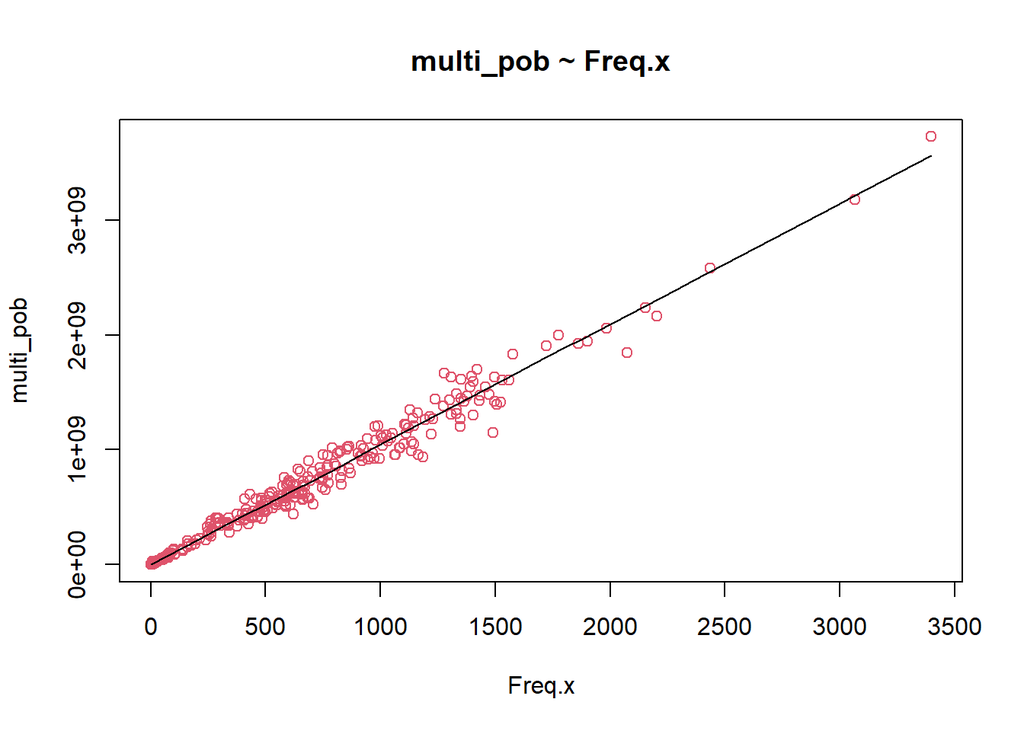

```r
scatter.smooth(x=h_y_m_comuna_corr_01$Freq.x, y=h_y_m_comuna_corr_01$multi_pob, main="multi_pob ~ Freq.x",
     xlab = "Freq.x",
     ylab = "multi_pob",
           col = 2)
```

### 7.2 Outliers

Hemos demostrado en el punto 5.7.2 de [aquí](https://rpubs.com/dataintelligence/expansion_viviendas_001) que la exclusión de ouliers no genera ninguna mejora en el modelo de regresión.

### 7.3 Modelo lineal

Aplicaremos un análisis de regresión lineal del ingreso expandido por zona sobre las frecuencias de respuestas zonales.

```r
linearMod <- lm( multi_pob~(Freq.x) , data=h_y_m_comuna_corr_01)
summary(linearMod)
```

```
##
## Call:
## lm(formula = multi_pob ~ (Freq.x), data = h_y_m_comuna_corr_01)
##
## Residuals:
##        Min         1Q     Median         3Q        Max
## -398994690  -38506526   -3413955   43221375  338806994
##
## Coefficients:
##             Estimate Std. Error t value Pr(>|t|)
## (Intercept)  3061300    8523956   0.359     0.72
## Freq.x       1038397       9871 105.193   <2e-16 ***
## ---
## Signif. codes:  0 '***' 0.001 '**' 0.01 '*' 0.05 '.' 0.1 ' ' 1
##
## Residual standard error: 91130000 on 290 degrees of freedom
## Multiple R-squared:  0.9745, Adjusted R-squared:  0.9744
## F-statistic: 1.107e+04 on 1 and 290 DF,  p-value: < 2.2e-16
```

### 7.4 Gráfica de la recta de regresión lineal

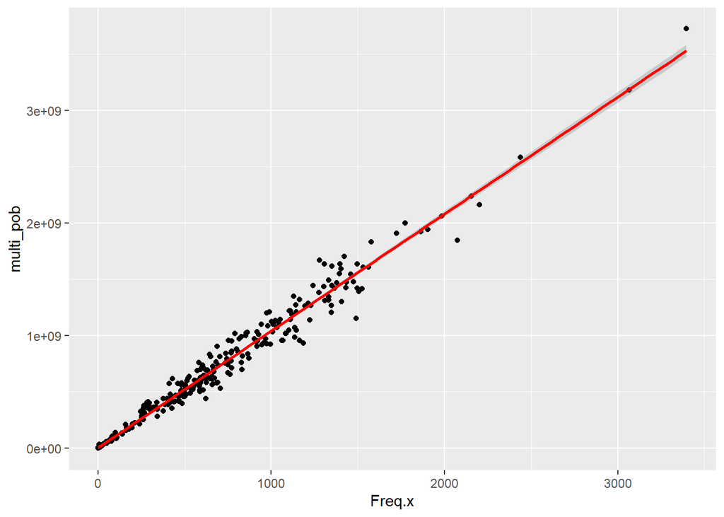

```r
ggplot(h_y_m_comuna_corr_01, aes(x = Freq.x , y = multi_pob)) +
  geom_point() +
  stat_smooth(method = "lm", col = "red")
```

## 8 Modelos alternativos

```r
### 8.1 Modelo cuadrático

linearMod <- lm( multi_pob~(Freq.x^2) , data=h_y_m_comuna_corr_01)
datos <- summary(linearMod)
dato <- datos$adj.r.squared
modelo <- "cuadrático"
sintaxis <- "linearMod <- lm( multi_pob~(Freq.x^2) , data=h_y_m_comuna_corr_01)"
latex <- "$$ '\'hat Y = '\'beta_0 + '\'beta_1  X^2  $$"
modelos1 <- cbind(modelo,dato,sintaxis,latex)

### 8.2 Modelo cúbico

linearMod <- lm( multi_pob~(Freq.x^3) , data=h_y_m_comuna_corr_01)
datos <- summary(linearMod)
dato <- datos$adj.r.squared
modelo <- "cúbico"
sintaxis <- "linearMod <- lm( multi_pob~(Freq.x^3) , data=h_y_m_comuna_corr_01)"
latex <- "$$ '\'hat Y = '\'beta_0 + '\'beta_1  X^3  $$"
modelos2 <- cbind(modelo,dato,sintaxis,latex)

### 8.3 Modelo logarítmico

linearMod <- lm( multi_pob~log(Freq.x) , data=h_y_m_comuna_corr_01)
datos <- summary(linearMod)
dato <- datos$adj.r.squared
modelo <- "logarítmico"
sintaxis <- "linearMod <- lm( multi_pob~log(Freq.x) , data=h_y_m_comuna_corr_01)"
latex <- "$$ '\'hat Y = '\'beta_0 + '\'beta_1 ln X  $$"
modelos3 <- cbind(modelo,dato,sintaxis,latex)

### 8.5 Modelo con raíz cuadrada

linearMod <- lm( multi_pob~sqrt(Freq.x) , data=h_y_m_comuna_corr_01)
datos <- summary(linearMod)
dato <- datos$adj.r.squared
modelo <- "raíz cuadrada"
sintaxis <- "linearMod <- lm( multi_pob~sqrt(Freq.x) , data=h_y_m_comuna_corr_01)"
latex <- "$$ '\'hat Y = '\'beta_0 + '\'beta_1  '\'sqrt {X}  $$"
modelos5 <- cbind(modelo,dato,sintaxis,latex)

### 8.6 Modelo raíz-raíz

linearMod <- lm( sqrt(multi_pob)~sqrt(Freq.x) , data=h_y_m_comuna_corr_01)
datos <- summary(linearMod)
dato <- datos$adj.r.squared
modelo <- "raíz-raíz"
sintaxis <- "linearMod <- lm( sqrt(multi_pob)~sqrt(Freq.x) , data=h_y_m_comuna_corr_01)"
latex <- "$$ '\'hat Y = {'\'beta_0}^2 + 2  '\'beta_0  '\'beta_1 '\'sqrt{X}+  '\'beta_1^2 X  $$"
modelos6 <- cbind(modelo,dato,sintaxis,latex)

### 8.7 Modelo log-raíz

linearMod <- lm( log(multi_pob)~sqrt(Freq.x) , data=h_y_m_comuna_corr_01)
datos <- summary(linearMod)
dato <- datos$adj.r.squared
modelo <- "log-raíz"
sintaxis <- "linearMod <- lm( log(multi_pob)~sqrt(Freq.x) , data=h_y_m_comuna_corr_01)"
latex <- "$$ '\'hat Y = e^{'\'beta_0 + '\'beta_1 '\'sqrt{X}} $$"
modelos7 <- cbind(modelo,dato,sintaxis,latex)

### 8.8 Modelo raíz-log

linearMod <- lm( sqrt(multi_pob)~log(Freq.x) , data=h_y_m_comuna_corr_01)
datos <- summary(linearMod)
dato <- datos$adj.r.squared
modelo <- "raíz-log"
sintaxis <- "linearMod <- lm( sqrt(multi_pob)~log(Freq.x) , data=h_y_m_comuna_corr_01)"
latex <- "$$ '\'hat Y = {'\'beta_0}^2 + 2  '\'beta_0  '\'beta_1 '\'ln{X}+  '\'beta_1^2 ln^2X  $$"
modelos8 <- cbind(modelo,dato,sintaxis,latex)

### 8.9 Modelo log-log

linearMod <- lm( log(multi_pob)~log(Freq.x) , data=h_y_m_comuna_corr_01)
datos <- summary(linearMod)
dato <- datos$adj.r.squared
modelo <- "log-log"
sintaxis <- "linearMod <- lm( log(multi_pob)~log(Freq.x) , data=h_y_m_comuna_corr_01)"
latex <- "$$ '\'hat Y = e^{'\'beta_0+'\'beta_1  ln{X}} $$"
modelos9 <- cbind(modelo,dato,sintaxis,latex)

modelos_bind <- rbind(modelos1,modelos2,modelos3,modelos5,modelos6,modelos7,modelos8,modelos9)
modelos_bind <- as.data.frame(modelos_bind)

modelos_bind <<- modelos_bind[order(modelos_bind$dato ),]
h_y_m_comuna_corr_01 <<- h_y_m_comuna_corr_01

kbl(modelos_bind) %>%
  kable_styling(bootstrap_options = c("striped", "hover")) %>%
  kable_paper() %>%
  scroll_box(width = "100%", height = "300px")
```

|  | modelo | dato | sintaxis | latex |
| --- | --- | --- | --- | --- |
| 3 | logarítmico | 0.560077556898266 | linearMod <- lm( multi_pob~log(Freq.x) , data=h_y_m_comuna_corr_01) | $$''hat Y = ''beta_0 + ''beta_1 ln X$$ |
| 6 | log-raíz | 0.799532370556495 | linearMod <- lm( log(multi_pob)~sqrt(Freq.x) , data=h_y_m_comuna_corr_01) | $$''hat Y = e^{''beta_0 + ''beta_1 ''sqrt{X}}$$ |
| 7 | raíz-log | 0.8202600529737 | linearMod <- lm( sqrt(multi_pob)~log(Freq.x) , data=h_y_m_comuna_corr_01) | $$''hat Y = {''beta_0}^2 + 2 ''beta_0 ''beta_1 ''ln{X}+ ''beta_1^2 ln^2X$$ |
| 4 | raíz cuadrada | 0.879451747617343 | linearMod <- lm( multi_pob~sqrt(Freq.x) , data=h_y_m_comuna_corr_01) | $$''hat Y = ''beta_0 + ''beta_1 ''sqrt {X}$$ |
| 1 | cuadrático | 0.974373927338671 | linearMod <- lm( multi_pob~(Freq.x^2) , data=h_y_m_comuna_corr_01) | $$''hat Y = ''beta_0 + ''beta_1 X^2$$ |
| 2 | cúbico | 0.974373927338671 | linearMod <- lm( multi_pob~(Freq.x^3) , data=h_y_m_comuna_corr_01) | $$''hat Y = ''beta_0 + ''beta_1 X^3$$ |
| 5 | raíz-raíz | 0.983329238506347 | linearMod <- lm( sqrt(multi_pob)~sqrt(Freq.x) , data=h_y_m_comuna_corr_01) | $$''hat Y = {''beta_0}^2 + 2 ''beta_0 ''beta_1 ''sqrt{X}+ ''beta_1^2 X$$ |
| 8 | log-log | 0.985090264362618 | linearMod <- lm( log(multi_pob)~log(Freq.x) , data=h_y_m_comuna_corr_01) | $$''hat Y = e^{''beta_0+''beta_1 ln{X}}$$ |

```r
h_y_m_comuna_corr <- h_y_m_comuna_corr_01
metodo <- 8


switch (metodo,
        case = linearMod <- lm( multi_pob~(Freq.x^2) , data=h_y_m_comuna_corr),
        case = linearMod <- lm( multi_pob~(Freq.x^3) , data=h_y_m_comuna_corr),
        case = linearMod <- lm( multi_pob~log(Freq.x) , data=h_y_m_comuna_corr),
        case = linearMod <- lm( multi_pob~sqrt(Freq.x) , data=h_y_m_comuna_corr),
        case = linearMod <- lm( sqrt(multi_pob)~sqrt(Freq.x) , data=h_y_m_comuna_corr),
        case = linearMod <- lm( log(multi_pob)~sqrt(Freq.x) , data=h_y_m_comuna_corr),
        case = linearMod <- lm( sqrt(multi_pob)~log(Freq.x) , data=h_y_m_comuna_corr),
        case = linearMod <- lm( log(multi_pob)~log(Freq.x) , data=h_y_m_comuna_corr)
)
summary(linearMod)
```

```
##
## Call:
## lm(formula = log(multi_pob) ~ log(Freq.x), data = h_y_m_comuna_corr)
##
## Residuals:
##      Min       1Q   Median       3Q      Max
## -1.24745 -0.09811 -0.00592  0.09980  1.44675
##
## Coefficients:
##              Estimate Std. Error t value Pr(>|t|)
## (Intercept) 13.629650   0.045295   300.9   <2e-16 ***
## log(Freq.x)  1.034797   0.007463   138.7   <2e-16 ***
## ---
## Signif. codes:  0 '***' 0.001 '**' 0.01 '*' 0.05 '.' 0.1 ' ' 1
##
## Residual standard error: 0.2116 on 290 degrees of freedom
## Multiple R-squared:  0.9851, Adjusted R-squared:  0.9851
## F-statistic: 1.923e+04 on 1 and 290 DF,  p-value: < 2.2e-16
```

```r
aa <- linearMod$coefficients[1]
aa
```

```
## (Intercept)
##    13.62965
```

```r
bb <- linearMod$coefficients[2]
bb
```

```
## log(Freq.x)
##    1.034797
```

## 9 Modelo log-log (**log-log**)

Es éste el modelo que nos entrega el mayor coeficiente de determinación de todos (0.9851).

### 9.1 Diagrama de dispersión sobre **log-log**

Desplegamos una curva suavizada por loess en el diagrama de dispersión.

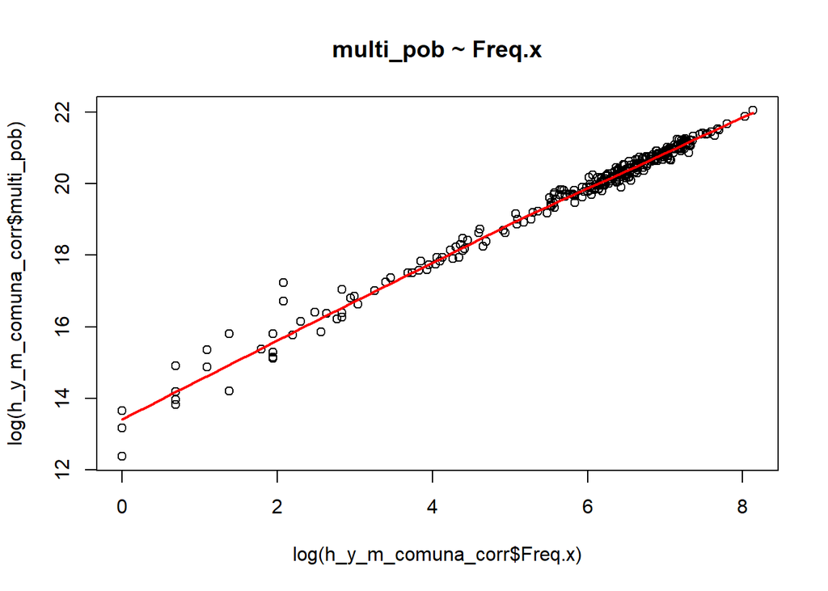

```r
scatter.smooth(x=log(h_y_m_comuna_corr$Freq.x), y=log(h_y_m_comuna_corr$multi_pob), lpars = list(col = "red", lwd = 2, lty = 1), main="multi_pob ~ Freq.x")
```

### 9.2 Modelo **log-log**

Observemos nuevamente el resultado sobre **log-log**.

```r
linearMod <- lm(log( multi_pob)~log(Freq.x) , data=h_y_m_comuna_corr)
summary(linearMod)
```

```
##
## Call:
## lm(formula = log(multi_pob) ~ log(Freq.x), data = h_y_m_comuna_corr)
##
## Residuals:
##      Min       1Q   Median       3Q      Max
## -1.24745 -0.09811 -0.00592  0.09980  1.44675
##
## Coefficients:
##              Estimate Std. Error t value Pr(>|t|)
## (Intercept) 13.629650   0.045295   300.9   <2e-16 ***
## log(Freq.x)  1.034797   0.007463   138.7   <2e-16 ***
## ---
## Signif. codes:  0 '***' 0.001 '**' 0.01 '*' 0.05 '.' 0.1 ' ' 1
##
## Residual standard error: 0.2116 on 290 degrees of freedom
## Multiple R-squared:  0.9851, Adjusted R-squared:  0.9851
## F-statistic: 1.923e+04 on 1 and 290 DF,  p-value: < 2.2e-16
```

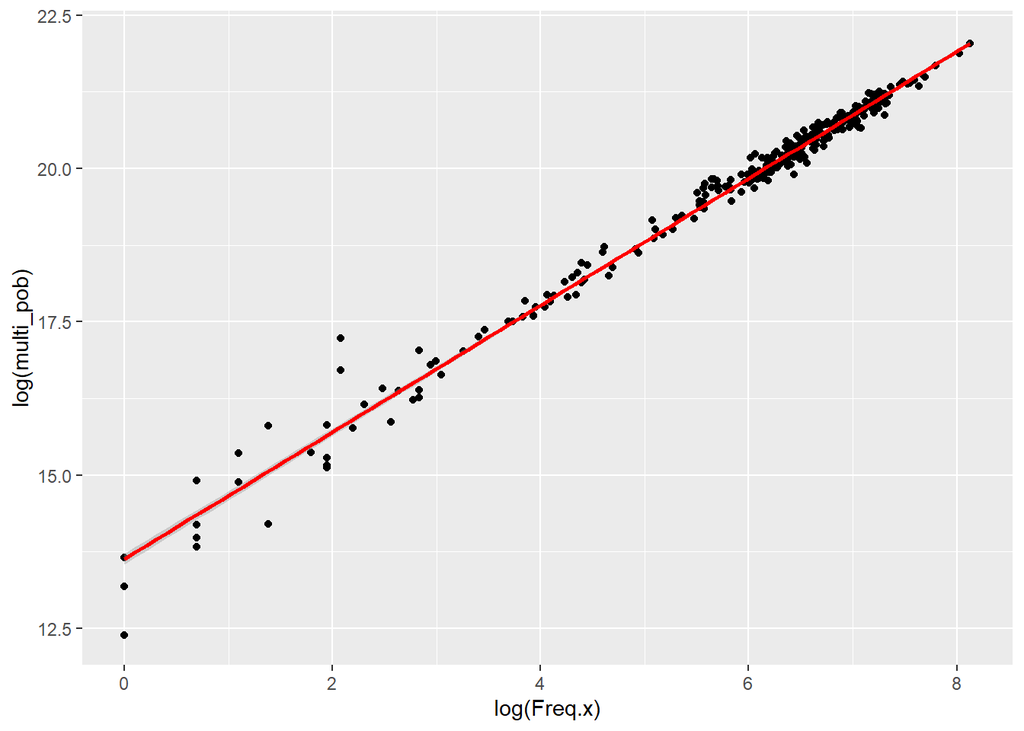

```r
ggplot(h_y_m_comuna_corr, aes(x = log(Freq.x) , y = log(multi_pob))) + geom_point() + stat_smooth(method = "lm", col = "red")
```

### 9.3 Análisis de residuos

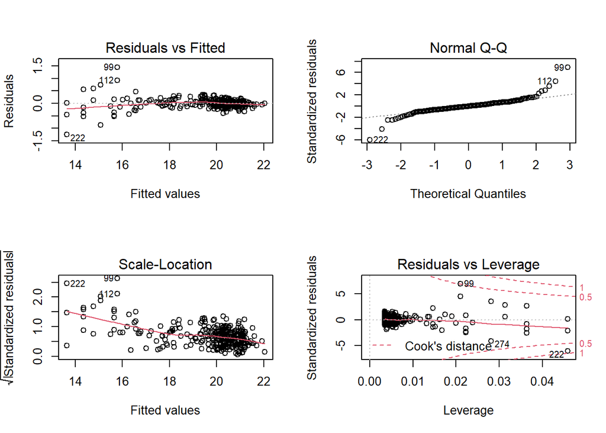

```r
par(mfrow = c (2,2))
plot(linearMod)
```

### 9.4 Ecuación del modelo

$$\hat Y = e^{13.62965 +1.034797 \cdot ln{X}}$$

## 10 Aplicación la regresión a los valores de la variable a nivel de zona

Esta nueva variable se llamará: est_ing

```r
h_y_m_comuna_corr$est_ing <- exp(aa+bb * log(h_y_m_comuna_corr$Freq.x))

r3_100 <- h_y_m_comuna_corr[c(1:100),]
kbl(r3_100) %>%
  kable_styling(bootstrap_options = c("striped", "hover")) %>%
  kable_paper() %>%
  scroll_box(width = "100%", height = "300px")
```

| zona | código.x | Freq.x | anio | comuna.x | promedio_i | año | comuna.y | personas | Ingresos_expandidos | Freq.y | p_poblacional | código.y | multi_pob | est_ing |
| --- | --- | --- | --- | --- | --- | --- | --- | --- | --- | --- | --- | --- | --- | --- |
| 6101011001 | 06101 | 1185 | 2017 | Rancagua | 318384.5 | 2017 | 6101 | 241774 | 76977097284 | 2931 | 0.0121229 | 06101 | 933185008 | 1258802889 |
| 6101021001 | 06101 | 467 | 2017 | Rancagua | 318384.5 | 2017 | 6101 | 241774 | 76977097284 | 1326 | 0.0054845 | 06101 | 422177864 | 480268531 |
| 6101031001 | 06101 | 251 | 2017 | Rancagua | 318384.5 | 2017 | 6101 | 241774 | 76977097284 | 893 | 0.0036935 | 06101 | 284317370 | 252614389 |
| 6101041001 | 06101 | 478 | 2017 | Rancagua | 318384.5 | 2017 | 6101 | 241774 | 76977097284 | 1599 | 0.0066136 | 06101 | 509096837 | 491979475 |
| 6101041002 | 06101 | 1490 | 2017 | Rancagua | 318384.5 | 2017 | 6101 | 241774 | 76977097284 | 3616 | 0.0149561 | 06101 | 1151278400 | 1595463513 |
| 6101051001 | 06101 | 749 | 2017 | Rancagua | 318384.5 | 2017 | 6101 | 241774 | 76977097284 | 2105 | 0.0087065 | 06101 | 670199400 | 783047811 |
| 6101051002 | 06101 | 549 | 2017 | Rancagua | 318384.5 | 2017 | 6101 | 241774 | 76977097284 | 1634 | 0.0067584 | 06101 | 520240294 | 567785509 |
| 6101051003 | 06101 | 685 | 2017 | Rancagua | 318384.5 | 2017 | 6101 | 241774 | 76977097284 | 1810 | 0.0074863 | 06101 | 576275969 | 713916136 |
| 6101051004 | 06101 | 586 | 2017 | Rancagua | 318384.5 | 2017 | 6101 | 241774 | 76977097284 | 1724 | 0.0071306 | 06101 | 548894901 | 607428581 |
| 6101051005 | 06101 | 466 | 2017 | Rancagua | 318384.5 | 2017 | 6101 | 241774 | 76977097284 | 1297 | 0.0053645 | 06101 | 412944714 | 479204373 |
| 6101061001 | 06101 | 1223 | 2017 | Rancagua | 318384.5 | 2017 | 6101 | 241774 | 76977097284 | 3575 | 0.0147865 | 06101 | 1138224635 | 1300597290 |
| 6101061002 | 06101 | 514 | 2017 | Rancagua | 318384.5 | 2017 | 6101 | 241774 | 76977097284 | 1868 | 0.0077262 | 06101 | 594742271 | 530370734 |
| 6101061003 | 06101 | 672 | 2017 | Rancagua | 318384.5 | 2017 | 6101 | 241774 | 76977097284 | 1945 | 0.0080447 | 06101 | 619257878 | 699900559 |
| 6101061004 | 06101 | 624 | 2017 | Rancagua | 318384.5 | 2017 | 6101 | 241774 | 76977097284 | 2013 | 0.0083260 | 06101 | 640908025 | 648233860 |
| 6101061005 | 06101 | 646 | 2017 | Rancagua | 318384.5 | 2017 | 6101 | 241774 | 76977097284 | 1941 | 0.0080282 | 06101 | 617984340 | 671897879 |
| 6101061006 | 06101 | 500 | 2017 | Rancagua | 318384.5 | 2017 | 6101 | 241774 | 76977097284 | 1440 | 0.0059560 | 06101 | 458473699 | 515429306 |
| 6101061007 | 06101 | 574 | 2017 | Rancagua | 318384.5 | 2017 | 6101 | 241774 | 76977097284 | 1880 | 0.0077759 | 06101 | 598562885 | 594561548 |
| 6101061008 | 06101 | 414 | 2017 | Rancagua | 318384.5 | 2017 | 6101 | 241774 | 76977097284 | 1255 | 0.0051908 | 06101 | 399572564 | 423981699 |
| 6101061009 | 06101 | 495 | 2017 | Rancagua | 318384.5 | 2017 | 6101 | 241774 | 76977097284 | 1458 | 0.0060304 | 06101 | 464204620 | 510096587 |
| 6101071001 | 06101 | 823 | 2017 | Rancagua | 318384.5 | 2017 | 6101 | 241774 | 76977097284 | 3085 | 0.0127599 | 06101 | 982216223 | 863237184 |
| 6101071002 | 06101 | 519 | 2017 | Rancagua | 318384.5 | 2017 | 6101 | 241774 | 76977097284 | 1951 | 0.0080695 | 06101 | 621168185 | 535710412 |
| 6101071003 | 06101 | 410 | 2017 | Rancagua | 318384.5 | 2017 | 6101 | 241774 | 76977097284 | 1805 | 0.0074656 | 06101 | 574684046 | 419743427 |
| 6101071004 | 06101 | 739 | 2017 | Rancagua | 318384.5 | 2017 | 6101 | 241774 | 76977097284 | 2369 | 0.0097984 | 06101 | 754252912 | 772231966 |
| 6101071005 | 06101 | 136 | 2017 | Rancagua | 318384.5 | 2017 | 6101 | 241774 | 76977097284 | 411 | 0.0016999 | 06101 | 130856035 | 133986939 |
| 6101071006 | 06101 | 482 | 2017 | Rancagua | 318384.5 | 2017 | 6101 | 241774 | 76977097284 | 1821 | 0.0075318 | 06101 | 579778198 | 496240337 |
| 6101071007 | 06101 | 290 | 2017 | Rancagua | 318384.5 | 2017 | 6101 | 241774 | 76977097284 | 1281 | 0.0052983 | 06101 | 407850561 | 293335756 |
| 6101081001 | 06101 | 465 | 2017 | Rancagua | 318384.5 | 2017 | 6101 | 241774 | 76977097284 | 1438 | 0.0059477 | 06101 | 457836930 | 478140293 |
| 6101081002 | 06101 | 762 | 2017 | Rancagua | 318384.5 | 2017 | 6101 | 241774 | 76977097284 | 2053 | 0.0084914 | 06101 | 653643406 | 797115915 |
| 6101081003 | 06101 | 865 | 2017 | Rancagua | 318384.5 | 2017 | 6101 | 241774 | 76977097284 | 2627 | 0.0108655 | 06101 | 836396116 | 908863374 |
| 6101081004 | 06101 | 828 | 2017 | Rancagua | 318384.5 | 2017 | 6101 | 241774 | 76977097284 | 2379 | 0.0098398 | 06101 | 757436757 | 868664704 |

[output cut: 70 more lines]

## 11 División del valor estimado entre la población total de la zona para obtener el ingreso medio por zona

$$Ingreso \_ Medio\_zona = est\_ing / (personas * p\_poblacional)$$

```r
h_y_m_comuna_corr$ing_medio_zona <- h_y_m_comuna_corr$est_ing  /( h_y_m_comuna_corr$personas  * h_y_m_comuna_corr$p_poblacional)

r3_100 <- h_y_m_comuna_corr[c(1:100),]
kbl(r3_100) %>%
  kable_styling(bootstrap_options = c("striped", "hover")) %>%
  kable_paper() %>%
  scroll_box(width = "100%", height = "300px")
```

| zona | código.x | Freq.x | anio | comuna.x | promedio_i | año | comuna.y | personas | Ingresos_expandidos | Freq.y | p_poblacional | código.y | multi_pob | est_ing | ing_medio_zona |
| --- | --- | --- | --- | --- | --- | --- | --- | --- | --- | --- | --- | --- | --- | --- | --- |
| 6101011001 | 06101 | 1185 | 2017 | Rancagua | 318384.5 | 2017 | 6101 | 241774 | 76977097284 | 2931 | 0.0121229 | 06101 | 933185008 | 1258802889 | 429478.98 |
| 6101021001 | 06101 | 467 | 2017 | Rancagua | 318384.5 | 2017 | 6101 | 241774 | 76977097284 | 1326 | 0.0054845 | 06101 | 422177864 | 480268531 | 362193.46 |
| 6101031001 | 06101 | 251 | 2017 | Rancagua | 318384.5 | 2017 | 6101 | 241774 | 76977097284 | 893 | 0.0036935 | 06101 | 284317370 | 252614389 | 282882.85 |
| 6101041001 | 06101 | 478 | 2017 | Rancagua | 318384.5 | 2017 | 6101 | 241774 | 76977097284 | 1599 | 0.0066136 | 06101 | 509096837 | 491979475 | 307679.47 |
| 6101041002 | 06101 | 1490 | 2017 | Rancagua | 318384.5 | 2017 | 6101 | 241774 | 76977097284 | 3616 | 0.0149561 | 06101 | 1151278400 | 1595463513 | 441223.32 |
| 6101051001 | 06101 | 749 | 2017 | Rancagua | 318384.5 | 2017 | 6101 | 241774 | 76977097284 | 2105 | 0.0087065 | 06101 | 670199400 | 783047811 | 371994.21 |
| 6101051002 | 06101 | 549 | 2017 | Rancagua | 318384.5 | 2017 | 6101 | 241774 | 76977097284 | 1634 | 0.0067584 | 06101 | 520240294 | 567785509 | 347481.95 |
| 6101051003 | 06101 | 685 | 2017 | Rancagua | 318384.5 | 2017 | 6101 | 241774 | 76977097284 | 1810 | 0.0074863 | 06101 | 576275969 | 713916136 | 394428.80 |
| 6101051004 | 06101 | 586 | 2017 | Rancagua | 318384.5 | 2017 | 6101 | 241774 | 76977097284 | 1724 | 0.0071306 | 06101 | 548894901 | 607428581 | 352336.76 |
| 6101051005 | 06101 | 466 | 2017 | Rancagua | 318384.5 | 2017 | 6101 | 241774 | 76977097284 | 1297 | 0.0053645 | 06101 | 412944714 | 479204373 | 369471.37 |
| 6101061001 | 06101 | 1223 | 2017 | Rancagua | 318384.5 | 2017 | 6101 | 241774 | 76977097284 | 3575 | 0.0147865 | 06101 | 1138224635 | 1300597290 | 363803.44 |
| 6101061002 | 06101 | 514 | 2017 | Rancagua | 318384.5 | 2017 | 6101 | 241774 | 76977097284 | 1868 | 0.0077262 | 06101 | 594742271 | 530370734 | 283924.38 |
| 6101061003 | 06101 | 672 | 2017 | Rancagua | 318384.5 | 2017 | 6101 | 241774 | 76977097284 | 1945 | 0.0080447 | 06101 | 619257878 | 699900559 | 359846.05 |
| 6101061004 | 06101 | 624 | 2017 | Rancagua | 318384.5 | 2017 | 6101 | 241774 | 76977097284 | 2013 | 0.0083260 | 06101 | 640908025 | 648233860 | 322023.78 |
| 6101061005 | 06101 | 646 | 2017 | Rancagua | 318384.5 | 2017 | 6101 | 241774 | 76977097284 | 1941 | 0.0080282 | 06101 | 617984340 | 671897879 | 346160.68 |
| 6101061006 | 06101 | 500 | 2017 | Rancagua | 318384.5 | 2017 | 6101 | 241774 | 76977097284 | 1440 | 0.0059560 | 06101 | 458473699 | 515429306 | 357937.02 |
| 6101061007 | 06101 | 574 | 2017 | Rancagua | 318384.5 | 2017 | 6101 | 241774 | 76977097284 | 1880 | 0.0077759 | 06101 | 598562885 | 594561548 | 316256.14 |
| 6101061008 | 06101 | 414 | 2017 | Rancagua | 318384.5 | 2017 | 6101 | 241774 | 76977097284 | 1255 | 0.0051908 | 06101 | 399572564 | 423981699 | 337834.02 |
| 6101061009 | 06101 | 495 | 2017 | Rancagua | 318384.5 | 2017 | 6101 | 241774 | 76977097284 | 1458 | 0.0060304 | 06101 | 464204620 | 510096587 | 349860.49 |
| 6101071001 | 06101 | 823 | 2017 | Rancagua | 318384.5 | 2017 | 6101 | 241774 | 76977097284 | 3085 | 0.0127599 | 06101 | 982216223 | 863237184 | 279817.56 |
| 6101071002 | 06101 | 519 | 2017 | Rancagua | 318384.5 | 2017 | 6101 | 241774 | 76977097284 | 1951 | 0.0080695 | 06101 | 621168185 | 535710412 | 274582.48 |
| 6101071003 | 06101 | 410 | 2017 | Rancagua | 318384.5 | 2017 | 6101 | 241774 | 76977097284 | 1805 | 0.0074656 | 06101 | 574684046 | 419743427 | 232544.83 |
| 6101071004 | 06101 | 739 | 2017 | Rancagua | 318384.5 | 2017 | 6101 | 241774 | 76977097284 | 2369 | 0.0097984 | 06101 | 754252912 | 772231966 | 325973.81 |
| 6101071005 | 06101 | 136 | 2017 | Rancagua | 318384.5 | 2017 | 6101 | 241774 | 76977097284 | 411 | 0.0016999 | 06101 | 130856035 | 133986939 | 326002.28 |
| 6101071006 | 06101 | 482 | 2017 | Rancagua | 318384.5 | 2017 | 6101 | 241774 | 76977097284 | 1821 | 0.0075318 | 06101 | 579778198 | 496240337 | 272509.80 |
| 6101071007 | 06101 | 290 | 2017 | Rancagua | 318384.5 | 2017 | 6101 | 241774 | 76977097284 | 1281 | 0.0052983 | 06101 | 407850561 | 293335756 | 228989.66 |
| 6101081001 | 06101 | 465 | 2017 | Rancagua | 318384.5 | 2017 | 6101 | 241774 | 76977097284 | 1438 | 0.0059477 | 06101 | 457836930 | 478140293 | 332503.68 |
| 6101081002 | 06101 | 762 | 2017 | Rancagua | 318384.5 | 2017 | 6101 | 241774 | 76977097284 | 2053 | 0.0084914 | 06101 | 653643406 | 797115915 | 388268.83 |
| 6101081003 | 06101 | 865 | 2017 | Rancagua | 318384.5 | 2017 | 6101 | 241774 | 76977097284 | 2627 | 0.0108655 | 06101 | 836396116 | 908863374 | 345970.07 |
| 6101081004 | 06101 | 828 | 2017 | Rancagua | 318384.5 | 2017 | 6101 | 241774 | 76977097284 | 2379 | 0.0098398 | 06101 | 757436757 | 868664704 | 365138.59 |

[output cut: 70 more lines]

Guardamos:

```r
saveRDS(h_y_m_comuna_corr, "P03C/region_06_P03C_u.rds")
```

## 12 Referencias

https://rpubs.com/osoramirez/316691

https://dataintelligencechile.shinyapps.io/casenfinal

Manual_de_usuario_Censo_2017_16R.pdf

http://www.censo2017.cl/microdatos/

Censo de Población y Vivienda

https://www.ine.cl/estadisticas/sociales/censos-de-poblacion-y-vivienda/poblacion-y-vivienda

http://r-statistics.co/Linear-Regression.html